# Grass Rockfish

*Sebastes rastrelliger*

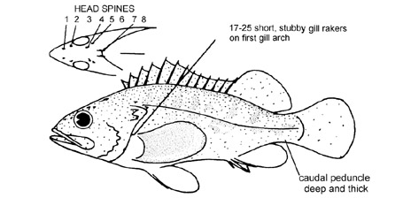

**Body color:** Dark olivaceous green, lighter ventrally; fins dark.

**Peritoneum color:** light **Shape between eyes:** convex

**Counts:** D:XIII,12-14, Ar:6, P1:18-20, GR:17-25, LLp:40-49, LLs:?-?, V:26

**Occurence:** Oregon - Baja California

**Depth:** 56 meters **Size:** 56 cm **Species code:** 30450

**Similar species:**

- *Brown rockfish* - gill rakers 25-29, not short; dark blotch on operculum (absent in Grass RF); body brown
- *Gopher rockfish* - gill rakers 26-30, not short; body brown, mottled w/ light areas
- *Black rockfish* - gill rakers 32-39, not short; body black to gray; head spines weak and count differs
- *Kelp rockfish* - gill rakers typically 31-34, not short; pectoral fin reaches vent (does not reach vent in Grass RF); body brown

Back to Group

**Corrections:** If you see mistakes or want to suggest changes, please create an [issue](https://github.com/zoyafuso-NOAA/RACE_Survey_App/issues) on the source repository or

*reach out to Liz Dawson (Liz.Dawson AT noaa.gov).*